# How do predators change population growth, part II?

Last week [I starting thinking about how predation might affect a species that otherwise experiences logistic growth](http://atyre2.github.io/2016/05/18/per-capita-growth-and-predators.html) due to intra-specific competition. I looked at predators with both Type I and Type II functional responses to their prey. What about predators with Type III responses?

## Predators that switch AND satiate

Type I predators have the same per capita attack rate regardless of how many prey there are. Type II predators are a bit more realistic, because they hit a maximum rate at which they can handle prey. There is one more real predator behavior that affects per capita attack rates. Sometimes predators stop paying attention to a given prey species as that species becomes less abundant. This is called “prey-switching”, because it arises when predators have choices. Predators that can choose between two prey species can devote more of their attention to the more abundant or easier to catch prey. As a result, the per capita attack rate initially gets higher as prey species increase. At some point, the attack rate reaches a maximum, and satiation starts to reduce per capita attack rates just as in a Type II functional response.

The simplest Type III functional response equation is

$$f(N) = \frac{aN^2}{1+ahN^2}$$

The only change is replacing $N$ with $N^2$. The per capita rate of death due to predation is no longer a maximum at $N = 0$. Instead there is a maximum at $N_{max} = \sqrt{1/ah}$, which is easiest to see in the following figure.

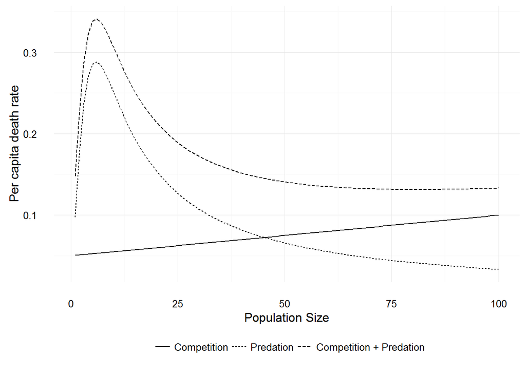

The combination of death due to intraspecific competition and death due to a Type III predator creates a non-linear response of total per capita death rates to population size. Total per capita death rate first increases as population size increases. The curve hits a maximum and then begins to decline with increasing population size just like a Type II curve. Eventually, as population size increases the per capita death due to predation asymptotes to 0. At large population sizes the death rate is again linear. If the per capita birth rate function is high enough, then a Type III predator also leads to dynamics that look very much like the logistic. How high is high enough? Unfortunately that’s not as easy to work out as it was for the Type II curve! However, as long as $b(N_{max}) > d(N_{max}) + \frac{aN_{max}}{2}$, we’ll have something that looks logistic. The per capita birth rate has to be higher than the peak in the figure above.

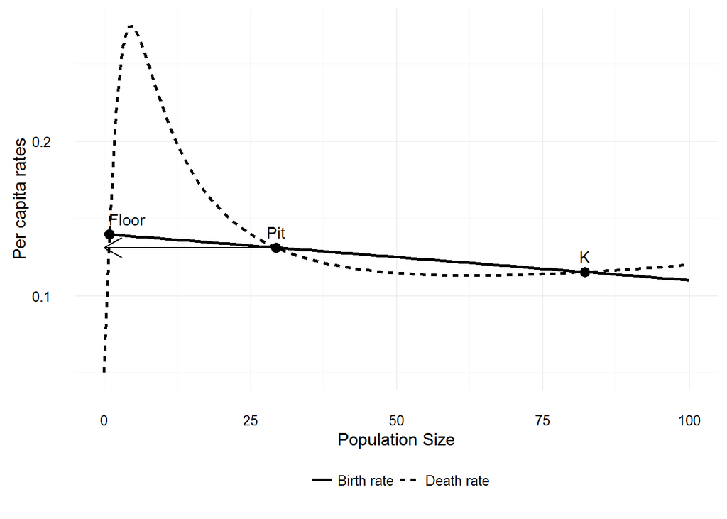

The logistic model turns out to be surprisingly good approximation of what happens with predation. The critical assumption is that the number of predators doesn’t change with changes in the number of the focal species.